# CÁLCULO DA MÉDIA DA NOTA PADRONIZADA CPC

# PROBLEMA

Calcular a média das nota padronizadas dos cursos da UFTM no CPC.

O que é o Conceito Preliminar de Curso? O conceito preliminar de curso (CPC) é calculado no ano seguinte ao da realização do Enade, em cada área, e considera, além do desempenho dos estudantes, o corpo docente, a infraestrutura e os recursos didático-pedagógicos, entre outros itens.

Mais informações  
http://portal.mec.gov.br/component/content/article?id=13074:o-que-e-o-conceito-preliminar-de-curso

# DATASET

https://www.gov.br/inep/pt-br/acesso-a-informacao/dados-abertos/indicadores-educacionais/indicadores-de-qualidade-da-educacao-superior

CARREGAR MÓDULOS

```r
library(dplyr)
library(stringr)

library(ggplot2)
```

CARREGAR O DATASET

```r
dados <- read.csv2("DADOS/Portal_CPC_Edição2019_atualizado.csv")
```

VERIFICAR O TAMANHO DO DATASET

```r
dim(dados)
```

```
[1] 8368   39
```

VERIFICAR OS NOMES DAS COLUNAS DO DATASET

```r
colnames(dados)
```

```
 [1] "Ano"
 [2] "Código.da.Área"
 [3] "Área.de.Avaliação"
 [4] "Código.da.IES"
 [5] "Nome.da.IES"
 [6] "Sigla.da.IES"
 [7] "Organização.Acadêmica"
 [8] "Categoria.Administrativa"
 [9] "Código.do.Curso"
[10] "Modalidade.de.Ensino"
[11] "Código.do.Município"
[12] "Município.do.Curso"
[13] "Sigla.da.UF"
[14] "Nº.de.Concluintes.Inscritos"
[15] "Nº.de.Concluintes.Participantes"
```

[output cut: 24 more lines]

VERIFICAR OS TIPOS DA VARIÁVEL CPC_FAIXA

```r
unique(dados$CPC..Faixa.)
```

```
[1] "3"  "4"  "5"  "2"  "1"  "SC" ""
```

EXCLUIR OS VALORES MISSING

```r
idexcluir <- which(dados$CPC..Faixa. %in% c('SC', ''))

dados <- dados[-idexcluir, ]
```

CRIAR UM VETOR COM AS VARIÁVEIS CHAVE PARA CÁLCULO

```r
colunas <- c("Nota.Padronizada...Regime.de.Trabalho",
             "Nota.Padronizada...Doutores",
             "Nota.Padronizada...Mestres",
             "Nota.Padronizada...Oportunidade.de.Ampliação.da.Formação",
             "Nota.Padronizada...Infraestrutura.e.Instalações.Físicas",
             "Nota.Padronizada...Organização.Didático.Pedagógica")
```

VERIFICAR OS TIPOS DE DADOS DA COLUNAS

```r
glimpse(dados[, colunas])
```

```
Rows: 8,188
Columns: 6
$ Nota.Padronizada...Regime.de.Trabalho                    <dbl> 5.000, 5.000, 5.000, 5.000, 5.000, 5.000, 5.0~
$ Nota.Padronizada...Doutores                              <dbl> 4.642, 4.007, 4.479, 4.027, 4.675, 3.801, 3.3~
$ Nota.Padronizada...Mestres                               <dbl> 5.000, 3.905, 4.693, 3.681, 5.000, 4.295, 4.6~
$ Nota.Padronizada...Oportunidade.de.Ampliação.da.Formação <dbl> 2.745, 2.008, 2.445, 1.531, 2.231, 2.383, 3.2~
$ Nota.Padronizada...Infraestrutura.e.Instalações.Físicas  <dbl> 2.379, 1.778, 1.627, 1.266, 1.332, 2.994, 2.9~
$ Nota.Padronizada...Organização.Didático.Pedagógica       <dbl> 1.937, 1.078, 1.347, 1.075, 3.568, 1.528, 2.9~
```

VERIFICAR SE AS COLUNAS TEM VALORES MISSING

```r
sapply(dados[, colunas], function(x) sum(is.na(x)))
```

```
                   Nota.Padronizada...Regime.de.Trabalho
                                                       0
                             Nota.Padronizada...Doutores
                                                       0
                              Nota.Padronizada...Mestres
                                                       0
Nota.Padronizada...Oportunidade.de.Ampliação.da.Formação
                                                       1
 Nota.Padronizada...Infraestrutura.e.Instalações.Físicas
                                                       1
      Nota.Padronizada...Organização.Didático.Pedagógica
                                                       1
```

VERIFICAR SE AS COLUNAS TEM VALORES NULOS

```r
sapply(dados[, colunas], function(x) sum(is.null(x)))
```

```
                   Nota.Padronizada...Regime.de.Trabalho
                                                       0
                             Nota.Padronizada...Doutores
                                                       0
                              Nota.Padronizada...Mestres
                                                       0
Nota.Padronizada...Oportunidade.de.Ampliação.da.Formação
                                                       0
 Nota.Padronizada...Infraestrutura.e.Instalações.Físicas
                                                       0
      Nota.Padronizada...Organização.Didático.Pedagógica
                                                       0
```

VERIFICAR O REGISTRO QUE CONTÉM VALORES MISSING

```r
idlinha <- which(is.na(dados[, 'Nota.Padronizada...Organização.Didático.Pedagógica']))
dados[idlinha, colunas ]
```

|  | Nota.Padronizada...Regime.de.Trabalho | Nota.Padronizada...Doutores | Nota.Padronizada...Mestres | Nota.Padronizada...Oportunidade.de.Ampliação.da.Formação | Nota.Padronizada...Infraestrutura.e.Instalações.Físicas | Nota.Padronizada...Organização.Didático.Pedagógica |
| --- | --- | --- | --- | --- | --- | --- |
| 3043 | 4.79 | 1.911 | 2.058 | NA | NA | NA |

EXCLUIR OS VALORES MISSING

```r
dados <- dados[-idlinha, ]
```

PLOTAR A VARIÁVEL QUE SERÁ CALCULADA

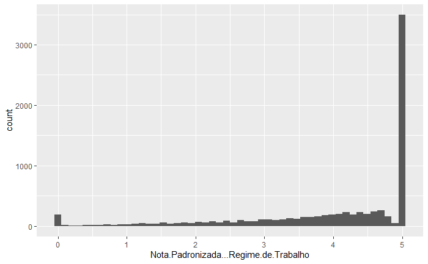

```r
ggplot(dados) +
  aes(Nota.Padronizada...Regime.de.Trabalho) +
  geom_histogram(bins = 50)
```

PLOTAR A VARIÁVEL QUE SERÁ CALCULADA

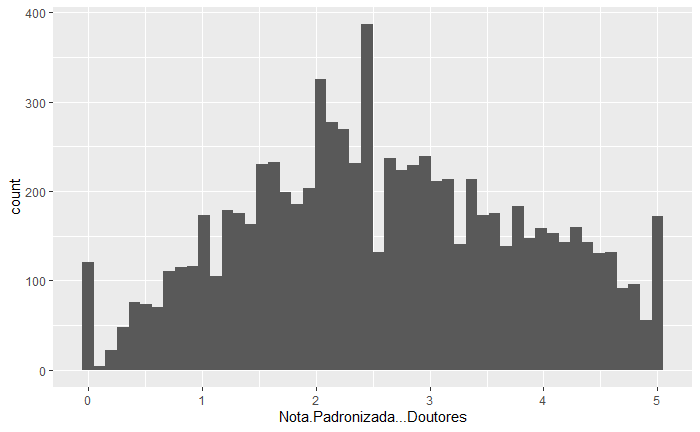

```r
ggplot(dados) +
  aes(Nota.Padronizada...Doutores) +
  geom_histogram(bins = 50)
```

PLOTAR A VARIÁVEL QUE SERÁ CALCULADA

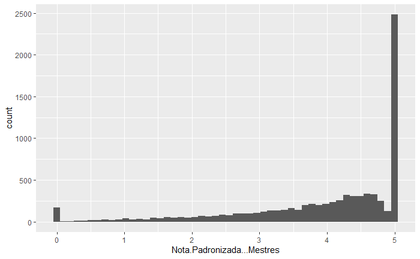

```r
ggplot(dados) +
  aes(Nota.Padronizada...Mestres) +
  geom_histogram(bins = 50)
```

PLOTAR A VARIÁVEL QUE SERÁ CALCULADA

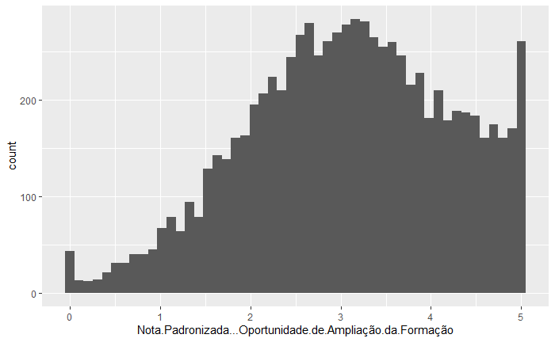

```r
ggplot(dados) +
  aes(Nota.Padronizada...Oportunidade.de.Ampliação.da.Formação) +
  geom_histogram(bins = 50)
```

PLOTAR A VARIÁVEL QUE SERÁ CALCULADA

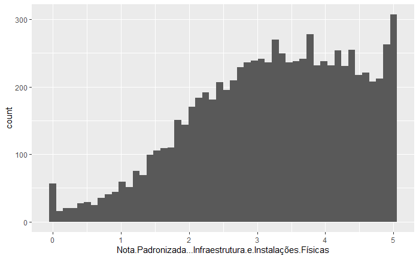

```r
ggplot(dados) +
  aes(Nota.Padronizada...Infraestrutura.e.Instalações.Físicas) +
  geom_histogram(bins = 50)
```

PLOTAR A VARIÁVEL QUE SERÁ CALCULADA

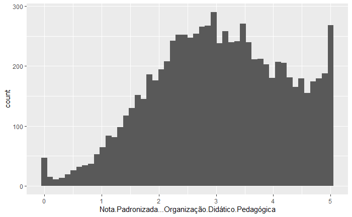

```r
ggplot(dados) +
  aes(Nota.Padronizada...Organização.Didático.Pedagógica) +
  geom_histogram(bins = 50)
```

VERIFICAR OS CURSOS QUE SERÃO CALCULADOS OS RANKING

```r
cursos <- dados[which(dados$Código.da.IES == 597), "Área.de.Avaliação"]
cursos
```

```
 [1] "MEDICINA"                      "ENFERMAGEM"                    "NUTRIÇÃO"
 [4] "FISIOTERAPIA"                  "BIOMEDICINA"                   "EDUCAÇÃO FÍSICA (BACHARELADO)"
 [7] "ENGENHARIA CIVIL"              "ENGENHARIA ELÉTRICA"           "ENGENHARIA MECÂNICA"
[10] "ENGENHARIA DE ALIMENTOS"       "ENGENHARIA QUÍMICA"            "ENGENHARIA DE PRODUÇÃO"
[13] "ENGENHARIA AMBIENTAL"
```

CRIAR A FUNÇÃO PARA FAZER O CÁLCULO DA NOTA PADRONIZADA

```r
calculo_ranking_nota_padronizada <- function(dados, coluna, cursos){
  "FUNÇÃO PARA FAZER O CÁLCULO DA NOTRA PADRONIZADA
  ENTRA
    DATASET, A COLUNA DO CÁLCULO E OS CURSOS
  SAI
    NOTA, MÉDIA PÚBLICA, MÉDIA PÚBLICA FEDERAL"

  tb <- c()
  for (curso in cursos){

    # PEGAR A NOTA DA INSTITUIÇÃO
    ddt <- dados %>%
      filter(`Área.de.Avaliação` == curso &
               `Código.da.IES` == 597)
    nota <- ddt[, coluna]

    # PEGAR A MÉDIA PÚBLICA
    ddt <- dados[dados['Área.de.Avaliação'] == curso, ]
    ddt <- ddt[ddt[, 'Categoria.Administrativa'] %in% c("Pública Federal", "Pública Estadual", "Pública Municipal" ), ]
    media_p <- round(mean(ddt[, coluna]), 4)

    # PEGAR A MÉDIA PÚBLICA FEDERAL
    ddt <- dados[dados['Área.de.Avaliação'] == curso, ]
    ddt <- ddt[ddt[, 'Categoria.Administrativa'] == "Pública Federal", ]
    media_pf <- round(mean(ddt[, coluna]), 4)

    linha <- c(nota, media_p, media_pf)
    tb <- rbind(tb, linha)
  }
  return(tb)
}
```

LOOP NAS VARIÁVEIS PARA FAZER OS CÁLCULOS

```r
for (coluna in colunas){

  tb <- calculo_ranking_nota_padronizada(dados, coluna, cursos)

  resultado <- as.data.frame(tb)
  rownames(resultado) <- cursos
  colnames(resultado) <- c(coluna, 'media_p', 'media_pf')
  resultado

  narquivo <- paste('RESULTADOS/CALCULO - CPC - NOTA PADRONIZADA - ', str_remove(coluna, 'Nota.Padronizada...'), '.csv', sep='')

  write.csv2(resultado, file = narquivo, na = "", quote = FALSE)
}
```

RESULTADO FINAL

```r
resultado
```

|  | Nota.Padronizada...Organização.Didático.Pedagógica | media_p | media_pf |
| --- | --- | --- | --- |
| MEDICINA | 2.472 | 2.4534 | 2.4003 |
| ENFERMAGEM | 3.410 | 3.0086 | 2.8390 |
| NUTRIÇÃO | 3.025 | 2.4897 | 2.5477 |
| FISIOTERAPIA | 3.773 | 2.6283 | 2.5295 |
| BIOMEDICINA | 1.958 | 2.2056 | 1.9605 |
| EDUCAÇÃO FÍSICA (BACHARELADO) | 2.684 | 2.1971 | 2.1184 |
| ENGENHARIA CIVIL | 1.996 | 2.2889 | 2.2774 |
| ENGENHARIA ELÉTRICA | 2.238 | 2.2680 | 2.3318 |
| ENGENHARIA MECÂNICA | 2.455 | 2.3651 | 2.4089 |
| ENGENHARIA DE ALIMENTOS | 2.300 | 2.2872 | 2.2460 |

[output cut: 3 more lines]